# Pengantar ggplot2 dalam Visualisasi Data

Dila Oktafiani-Institut Teknologi Statistika dan Bisnis Muhammadiyah Semarang

2025-01-16

# Pengantar ggplot2

**ggplot2** adalah salah satu paket paling populer di R untuk membuat visualisasi data. Dikenalkan oleh Hadley Wickham, **ggplot2** menggunakan prinsip-prinsip *Grammar of Graphics*, yang memungkinkan pengguna untuk membuat berbagai jenis grafik secara konsisten dan fleksibel. Dengan menggunakan konsep dasar ini, **ggplot2** memisahkan komponen-komponen penting dari visualisasi, seperti data, estetika (seperti warna dan bentuk), dan geometri (seperti titik atau garis), yang semuanya dapat digabungkan untuk menghasilkan plot yang informatif dan menarik.

Salah satu keuntungan utama menggunakan **ggplot2** adalah kemampuannya untuk membuat visualisasi yang kompleks dengan kode yang relatif sederhana. Misalnya, Anda dapat membuat plot titik, histogram, boxplot, hingga plot lebih canggih seperti heatmap dan peta interaktif hanya dengan beberapa baris kode. **ggplot2** juga mendukung fitur seperti *facetting*, yang memungkinkan untuk membagi data menjadi subgrup dan membuat plot terpisah untuk setiap subgrup tersebut, yang sangat berguna dalam analisis data yang besar dan beragam.

Selain itu, **ggplot2** sangat fleksibel dan dapat disesuaikan untuk berbagai tujuan visualisasi, baik itu untuk analisis eksplorasi data (EDA) atau untuk menghasilkan grafik yang siap digunakan dalam publikasi. Dengan kemampuan kustomisasi yang mendalam, pengguna dapat mengubah hampir setiap elemen plot, mulai dari tema, ukuran font, hingga posisi legenda. Hal ini menjadikan **ggplot2** pilihan yang sangat baik untuk para peneliti dan profesional yang ingin mempresentasikan data mereka dengan cara yang efektif dan estetis.

# Dasar-dasar ggplot

**ggplot2** adalah paket visualisasi data di R yang dirancang berdasarkan prinsip *Grammar of Graphics*. Dengan **ggplot2**, Anda dapat membuat berbagai jenis plot dengan mudah, mulai dari grafik titik (scatter plots), garis, hingga plot yang lebih kompleks seperti boxplot dan heatmap. Konsep utama di balik **ggplot2** adalah memisahkan elemen-elemen grafik seperti data, estetika (warna, ukuran, bentuk), dan geometri (titik, garis, histogram) untuk menghasilkan plot yang informatif.

## Struktur Dasar ggplot2

Pada dasarnya, setiap plot dengan **ggplot2** dimulai dengan fungsi `ggplot()`, diikuti oleh pemilihan elemen estetika (aesthetics) dan geometri (geoms). Berikut adalah struktur dasar kode untuk membuat plot:

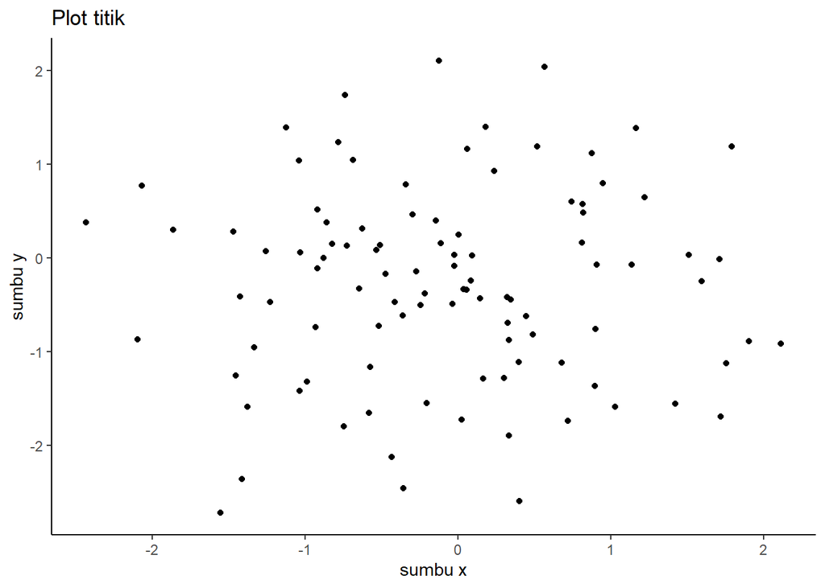

```r
library(ggplot2)
data <- data.frame(x = rnorm(100), y = rnorm(100))
ggplot(data, aes(x = x, y = y)) +
  geom_point() +
  labs(title = "Plot titik", x = "sumbu x", y = "sumbu y") +
  theme_classic()
```